# Using the data.generation function

Susumu Shikano

Last compiled at 12. April 2022

## Loading the function from github.

We first load the function, which is used to generate multiple datasets under specified assumptions.

```r
source("https://raw.githubusercontent.com/SuShikano/StatTeaching/main/func/data_generation.R")
```

## Generating two different datasets

```r
samples01 <- data.generation(sample.size=100,
                             n.sim=2,
                             n.iv=1,
                             x.mu=3,
                             x.Sigma=as.matrix(1,nrow=1),
                             para=c(1,5),
                             err.dist = "uniform",
                             err.disp = 20)
```

## Describing the generated data

The first generated dataset looks as follows:

```r
head(samples01$generated.data[[1]])
```

```
##          y       X1     error
## 1 11.13884 3.376590 -6.744108
## 2 19.76197 3.059140  3.466266
## 3 17.08405 2.639077  2.888662
## 4 17.97957 4.972502 -7.882943
## 5 14.38853 1.935086  3.713100
## 6 15.44021 2.679937  1.040523
```

… and the second generated data:

```r
head(samples01$generated.data[[2]])
```

```
##           y       X1     error
## 1 18.218811 2.024620  7.095709
## 2  9.005130 1.397406  1.018102
## 3  6.011398 1.918649 -4.581849
## 4  6.655926 3.059297 -9.640557
## 5  2.835174 1.975380 -8.041726
## 6 11.557145 3.279908 -5.842394
```

You can also plot y and x1 of both datasets:

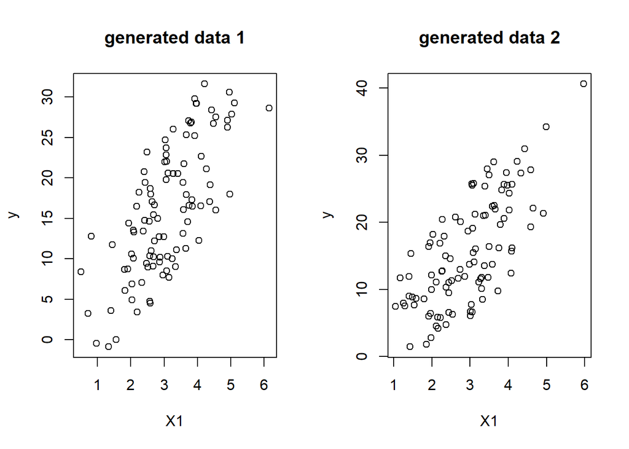

```r
par(mfrow=c(1,2))

for (i.fig in 1:2){
  plot(samples01$generated.data[[i.fig]]$y ~ samples01$generated.data[[i.fig]]$X1,
       xlab="X1",ylab="y",
       main=paste("generated data",i.fig)
       )
}
```

## Regressing y on X1.

By using each of the datasets, we can regress y on X1. As one can see below, both results are not identical with the true model $\hat y = 1 + 5 \times X1$.

```r
lm.outs <- vector(mode="list",length=2)
for (i in 1:2){
  print(paste("Generated data",i))

  lm.outs[[i]] <- lm(y ~ X1, data=samples01$generated.data[[i]])

  print(
    summary(lm.outs[[i]])
    )
}
```

```
## [1] "Generated data 1"
##
## Call:
## lm(formula = y ~ X1, data = samples01$generated.data[[i]])
##
## Residuals:
##    Min     1Q Median     3Q    Max
## -9.070 -4.798  0.230  4.467 10.297
##
## Coefficients:
##             Estimate Std. Error t value Pr(>|t|)
## (Intercept)  -0.5361     1.7063  -0.314    0.754
## X1            5.4061     0.5243  10.311   <2e-16 ***
## ---
## Signif. codes:  0 '***' 0.001 '**' 0.01 '*' 0.05 '.' 0.1 ' ' 1
##
## Residual standard error: 5.517 on 98 degrees of freedom
## Multiple R-squared:  0.5204, Adjusted R-squared:  0.5155
## F-statistic: 106.3 on 1 and 98 DF,  p-value: < 2.2e-16
##
## [1] "Generated data 2"
##
## Call:
## lm(formula = y ~ X1, data = samples01$generated.data[[i]])
##
## Residuals:
##      Min       1Q   Median       3Q      Max
## -10.3248  -5.4364   0.2277   4.1909   9.5517
##
## Coefficients:
##             Estimate Std. Error t value Pr(>|t|)
## (Intercept)  -1.3950     1.7794  -0.784    0.435
## X1            5.7801     0.5728  10.091   <2e-16 ***
## ---
## Signif. codes:  0 '***' 0.001 '**' 0.01 '*' 0.05 '.' 0.1 ' ' 1
##
## Residual standard error: 5.619 on 98 degrees of freedom
## Multiple R-squared:  0.5096, Adjusted R-squared:  0.5046
## F-statistic: 101.8 on 1 and 98 DF,  p-value: < 2.2e-16
```

The estimated regression lines go through the generated datasets:

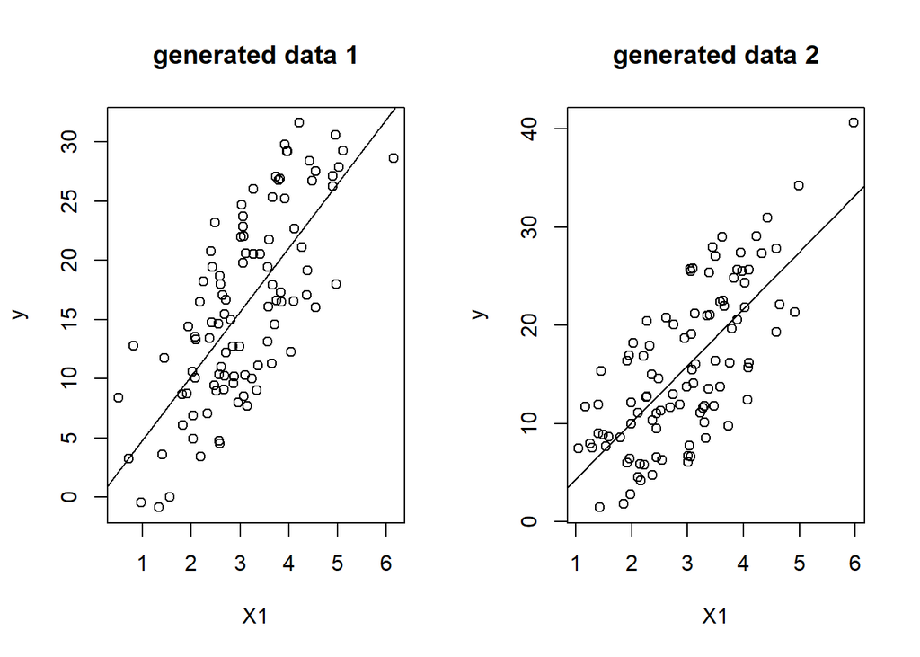

```r
par(mfrow=c(1,2))

for (i.fig in 1:2){
  plot(samples01$generated.data[[i.fig]]$y ~ samples01$generated.data[[i.fig]]$X1,
       xlab="X1",ylab="y",
       main=paste("generated data",i.fig)
       )
  abline(reg=lm.outs[[i.fig]])
}
```

## Checking the performance of the regression models using 1000 datasets

We generate 1000 datasets (n.sim=1000) based on the same set-up above.

```r
samples02 <- data.generation(sample.size=100,
                                  n.sim=1000,
                                  n.iv=1,
                             x.mu=3,
                             x.Sigma=as.matrix(1,nrow=1),
                             para=c(1,5),
                             err.dist = "uniform",
                             err.disp = 20)
```

Using each of the generated datasets, we regress y on X1 and collect the results:

```r
all.intercepts <- all.slopes <- matrix(NA,nrow=1000,ncol=4)
for(i.data in 1:1000){
  this.result <-
     summary(lm(y ~ X1,
                data=samples02$generated.data[[i.data]]))$coefficients
  all.intercepts[i.data,] <- this.result[1,]
  all.slopes[i.data,] <- this.result[2,]
}
```

Let’s check the distribution of the point estimates.

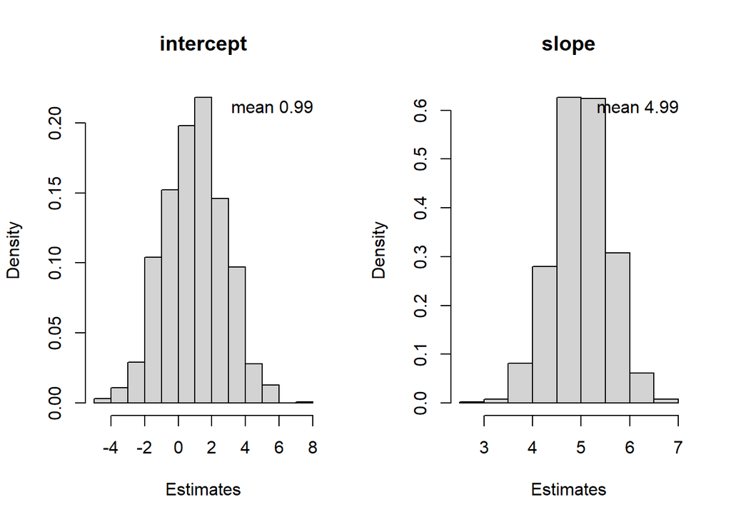

```r
par(mfrow=c(1,2))
for (i.fig in 1:2){
  if (i.fig==1) to.plot <- all.intercepts[,1]
  if (i.fig==2) to.plot <- all.slopes[,1]

  hist(to.plot,
       main=c("intercept","slope")[i.fig],
       xlab="Estimates",
       freq=F)
  legend("topright",
         paste("mean",round(mean(to.plot),2)),
         bty="n")

}
```

The means of the estimates are very close to the true value. If you use infinitely large number of datasets, the means are identical with the true value (no bias).

The regression lines based on 1000 datasets can be visualized in the following figure:

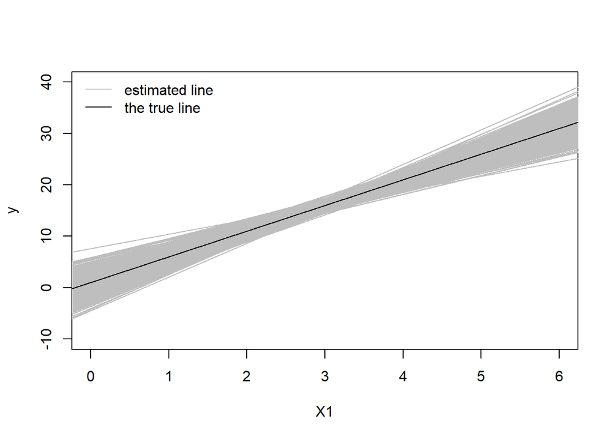

```r
plot(0,xlim=c(0,6),ylim=c(-10,40),type="n",
     xlab="X1",ylab="y")
# plot the estimated regression lines (grey color)
for(i.data in 1:1000){
  abline(coef=c(all.intercepts[i.data,1] ,all.slopes[i.data,1] ),
         col="grey")
}
# plot the true regression line (black)
abline(coef=c(1,5))
legend("topleft",
       c("estimated line","the true line"),
       lty=1,
       col=c("grey","black"),
       bty="n")
```

The black line is the true regression line, around which the grey estimated regression lines based on the random samples can be found.

Let’s check the 95% confidence intervals of the slope estimates:

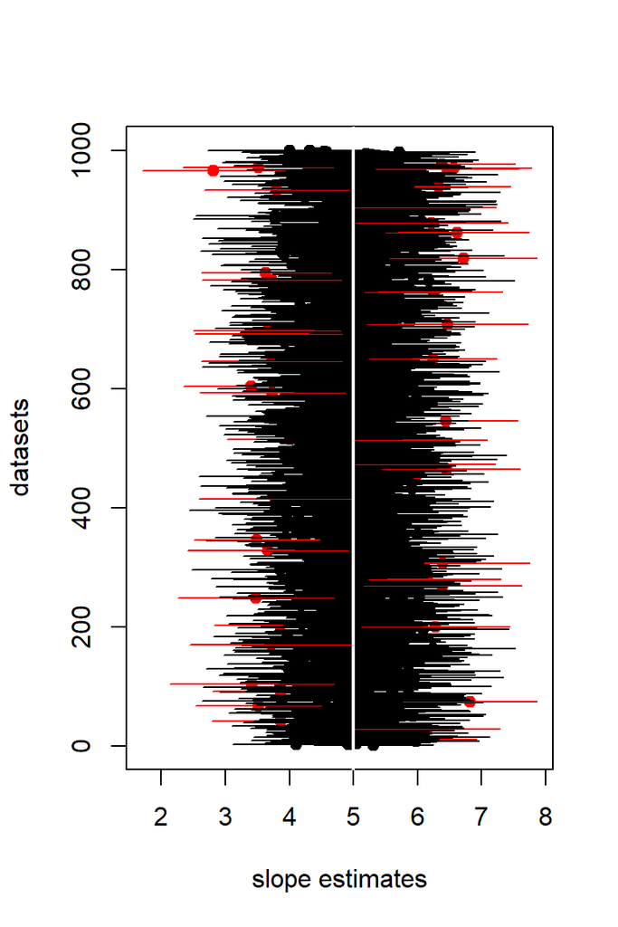

```r
ci.prob <- .95
lo.prob <- (1-ci.prob)/2
up.prob <- 1-lo.prob

lo.bounds <- all.slopes[,1] + qt(lo.prob,df=100-2)*all.slopes[,2]
up.bounds <- all.slopes[,1] + qt(up.prob,df=100-2)*all.slopes[,2]

xrange <- range(c(lo.bounds,up.bounds))

without.true.value <- ifelse(lo.bounds>5 | up.bounds<5,1,0)

plot(all.slopes[,1],1:1000,xlim=xrange,
     pch=19,
     col=c("black","red")[without.true.value+1],
     xlab="slope estimates",
     ylab="datasets")
for (i.data in 1:1000){
  lines(c(lo.bounds[i.data],up.bounds[i.data]),rep(i.data,2),
        col=c("black","red")[without.true.value[i.data]+1])
}
abline(v=5,col="white",lwd=2)
```

4.4% of all confidence intervalls (red color) do not include the true slope.